# Executive Summary

Rose Goueth, Alfonzo Poire, Ariella Brenner

8/22/2019

## Why LACE scores are needed

LACE scores are a metric that could be used by everyone in a hospital or healthcare system. Physicians would be able to see the outcome of the regression and could tailor treatment options for patients at high risk of readmission. Financial analysists would be able to track vulnerable patients and general trends within the hospital to suggest possible improvements that would save the organization money and improve patient care quality. Use of this metric will allow desicion makers to see blind spots in the organization’s treatment options.

For instance, if we have efficient Congestive Heart Failure (CHF) treatments but outdated ones for stroke, then the comorbidity scores of strokes could increase. This trend would cause an increase in readmissions for stroke patients. LACE indices allow us to allocate more resources to vulnerabilities within the organization.

## Why do we track readmissions?

Tracking patient readmission is crucial for patient treatment and provider costs. 30 day readmission rates are a common indicator used to track quality of hospital care. If a clinician can accurately predict whether a patient will likely be readmitted then subsequent action can be taken to prevent the patient from returning. If this statistic is not improved, providers will be taking on additional avoidable costs leading to costly quality care for patients.

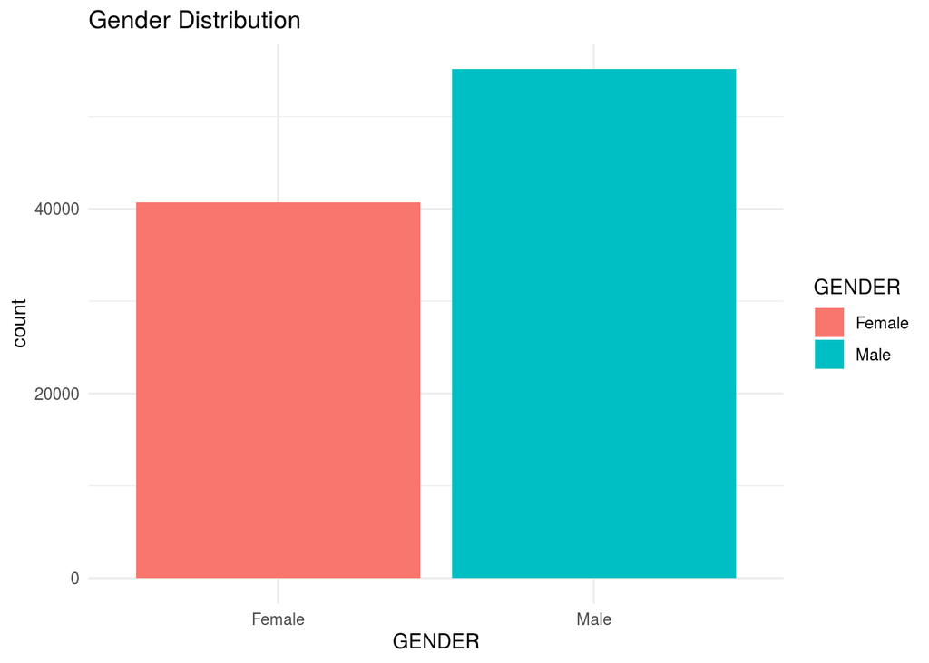

```r
ggplot(analytic,aes(GENDER,fill=GENDER))+geom_bar()+ggtitle("Gender Distribution")+theme_minimal()
```

## Why we chose gender

The first graph shows the distribution of genders within our data. We can see the data is skewed towards males. This is something we must take into account because our model may be more predictive for men than women.

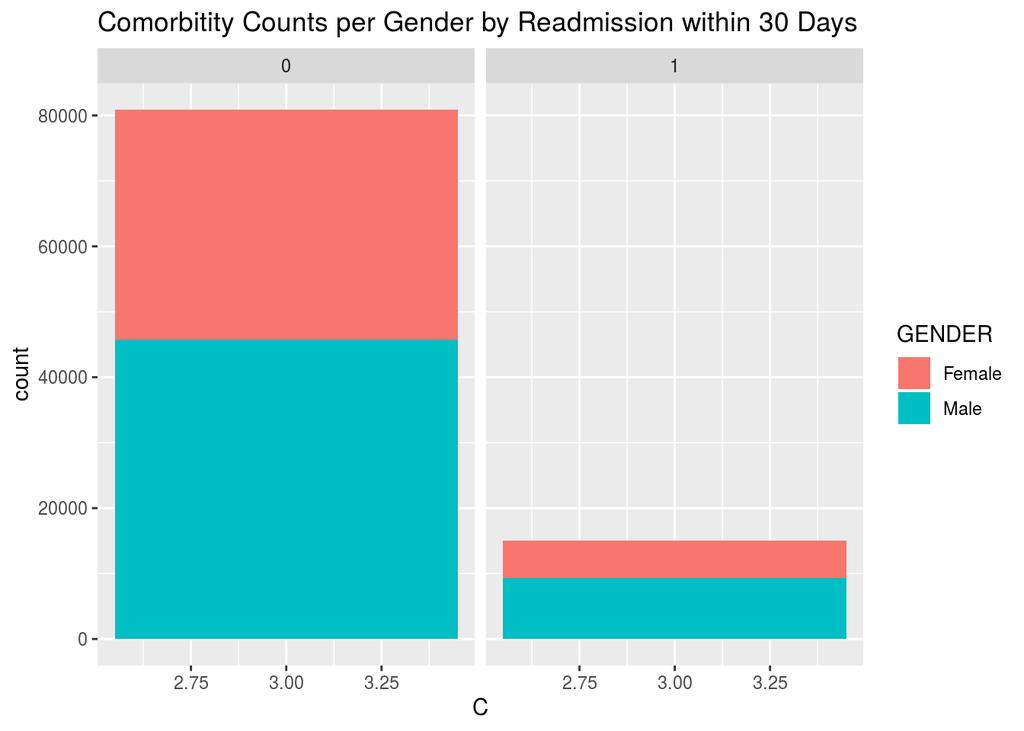

```r
ggplot(analytic,aes(C,fill=GENDER))+geom_bar()+facet_wrap(~Readmit30)+ggtitle("Comorbitity Counts per Gender by Readmission within 30 Days")
```

## Why gender and comorbities can affect readmissions

The second graph illustrates readmissions by comorbidity for each gender. This shows there are fewer people being readmitted (a good sign) but the co-morbidities we chose (Congestive Heart Failure and Stroke) do not seem to be highly correlated with readmissions. The figure also shows that there are more men who return then woman, however this may be an artifact of our data set rather than an actual factor.

```r
#run a simple logistic regression model just using LScore and Ascore
#we can cast AScore as categorical data using factor()
MyModel <- glm(Readmit30 ~ L + A + E + GENDER, family = "binomial", data=trainSet)

original <- glm(Readmit30 ~ L + A + E + C2, family = "binomial", data=trainSet)
```

```r
#Summarize the model
summary(MyModel)
```

```
##
## Call:
## glm(formula = Readmit30 ~ L + A + E + GENDER, family = "binomial",
##     data = trainSet)
##
## Deviance Residuals:
##     Min       1Q   Median       3Q      Max
## -1.0867  -0.6353  -0.5111  -0.3879   2.4748
##
## Coefficients:
##              Estimate Std. Error z value Pr(>|z|)
## (Intercept) -3.250179   0.034434  -94.39   <2e-16 ***
## L            0.235661   0.005813   40.54   <2e-16 ***
## A3           0.702974   0.020757   33.87   <2e-16 ***
## E            0.112715   0.010212   11.04   <2e-16 ***
## GENDERMale   0.229525   0.020983   10.94   <2e-16 ***
## ---
## Signif. codes:  0 '***' 0.001 '**' 0.01 '*' 0.05 '.' 0.1 ' ' 1
##
## (Dispersion parameter for binomial family taken to be 1)
##
##     Null deviance: 65677  on 75718  degrees of freedom
## Residual deviance: 62629  on 75714  degrees of freedom
##   (10584 observations deleted due to missingness)
## AIC: 62639
##
## Number of Fisher Scoring iterations: 4
```

```r
summary(original)
```

```
##
## Call:
## glm(formula = Readmit30 ~ L + A + E + C2, family = "binomial",
##     data = trainSet)
##
## Deviance Residuals:
##     Min       1Q   Median       3Q      Max
## -1.0506  -0.6453  -0.5172  -0.3927   2.4521
##
## Coefficients:
##              Estimate Std. Error z value Pr(>|z|)
## (Intercept) -3.107183   0.031849 -97.560   <2e-16 ***
## L            0.235435   0.005808  40.539   <2e-16 ***
## A3           0.702123   0.020739  33.855   <2e-16 ***
## E            0.112811   0.010205  11.055   <2e-16 ***
## C2          -0.041985   0.022763  -1.844   0.0651 .
## ---
## Signif. codes:  0 '***' 0.001 '**' 0.01 '*' 0.05 '.' 0.1 ' ' 1
##
## (Dispersion parameter for binomial family taken to be 1)
##
##     Null deviance: 65677  on 75718  degrees of freedom
## Residual deviance: 62747  on 75714  degrees of freedom
##   (10584 observations deleted due to missingness)
## AIC: 62757
##
## Number of Fisher Scoring iterations: 4
```

```r
#grab coefficients themselves
coef(MyModel)
```

```
## (Intercept)           L          A3           E  GENDERMale
##  -3.2501792   0.2356613   0.7029743   0.1127150   0.2295250
```

```r
coef(original)
```

```
## (Intercept)           L          A3           E          C2
## -3.10718254  0.23543455  0.70212257  0.11281072 -0.04198514
```

```r
#predict the logit instead for our testSet
modelPredictedLogOddsRatio <- predict(MyModel,newdata = testSet)
#add as another column in our table
testSetPred <- data.frame(testSet, predLogit = modelPredictedLogOddsRatio)
#transform the logit to the predictedOdds ratio
modelPredictedOddsRatio <- exp(modelPredictedLogOddsRatio)
#add as column in our table
testSetPred <- data.frame(testSetPred, predOR = modelPredictedOddsRatio)
#
final_coef<-exp(coef(MyModel))
final_coef
```

```
## (Intercept)           L          A3           E  GENDERMale
##  0.03876726  1.26574551  2.01975120  1.11931286  1.25800232
```

```r
modelPredictedLogOddsRatio1 <- predict(original,newdata = testSet)
#add as another column in our table
testSetPred1 <- data.frame(testSet, predLogit = modelPredictedLogOddsRatio1)
#transform the logit to the predictedOdds ratio
modelPredictedOddsRatio1 <- exp(modelPredictedLogOddsRatio1)
#add as column in our table
testSetPred <- data.frame(testSetPred1, predOR = modelPredictedOddsRatio1)
#
final_coef1<-exp(coef(original))
final_coef1
```

```
## (Intercept)           L          A3           E          C2
##  0.04472679  1.26545855  2.01803158  1.11942003  0.95888403
```

```r
totalCases <- sum(truthPredict)
misclassified <- truthPredict[1,2] + truthPredict[2,1]
accuracy <- (totalCases - misclassified) / totalCases

totalCases1 <- sum(truthPredict1)
misclassified1 <- truthPredict1[1,2] + truthPredict1[2,1]
accuracy1 <- (totalCases1 - misclassified1) / totalCases1

acc_table <- matrix(c(accuracy,accuracy1), ncol=2, byrow=TRUE)
colnames(acc_table) <- c("our model","original")
rownames(acc_table) <- "Accuracy"
acc_table <- as.table(acc_table)
acc_table
```

```
##          our model  original
## Accuracy 0.7723442 0.7566766
```

[figure not shown]

```r
pr <- prediction(modelPredictedProbabilities, testSet$Readmit30)
prf <- performance(pr, measure = "tpr", x.measure = "fpr")
plot(prf, main="Original Model ROC Curve")
```

[figure not shown]

```r
pr1 <- prediction(modelPredictedProbabilities1, testSet$Readmit30)
prf1 <- performance(pr1, measure = "tpr", x.measure = "fpr")
plot(prf1, main="Our Model ROC Curve")
```

```r
auc <- performance(pr, measure = "auc")
auc <- auc@y.values[[1]]

auc1 <- performance(pr1, measure = "auc")
auc1 <- auc1@y.values[[1]]

auc_table <- matrix(c(auc,auc1), ncol=2, byrow=TRUE)
colnames(auc_table) <- c("our model","original")
rownames(auc_table) <- "AUC"
auc_table <- as.table(auc_table)
auc_table
```

```
##     our model  original
## AUC 0.6580774 0.6505478
```